# g-2 Gallery Demo

```r
library(magrittr)
library(stringr)
library(Rcpp)
```

Let’s try to get a gallery demo to work with g-2 data. I have a centos7 docker container with the g-2 code and libraries in it.

In order for `Rcpp::sourceCpp` to do builds with the gallery and gm2 includes and libraries, we need to create an `Rcpp` *plugin*. The plugin is an *R* object that has build instructions for `Rcpp`. There are some examples at http://gallery.rcpp.org/articles/HRP/ and also see https://github.com/eddelbuettel/rcppgsl/blob/34ffe8dfe35e6faa1d975377464fe528c83cf791/R/inline.R#L44 .

Unforunately, though `PATH` and `LD_LIBRARY_PATH` propagate to *R* within RStudio, the other environment variables do not. In the shell, I made an `.Renviron` file by doing,

```bash
env | egrep '(_INC|_LIB=)' > Renviron
```

Here we determine the include paths (e.g. `ROOT_INC`). A future version should use `Sys.getenv()`…

```r
makeListWithNames <- function(bigList, prefix="-I ") {
  # Helper function to get a list in the form we want.
  # bigList has entries of the form...
  #  [[1]] BLA_INC
  #  [[2]] /path/to/inc
  #  Convert this to list with names=[[1]] and values=[[2]]

  theList  <- lapply(bigList, function(x) paste(prefix, x[2], sep=""))
  theNames <- sapply(bigList, function(x) x[1])
  names(theList) <- theNames
  theList
}
system(
    "env | grep _INC",
       intern=T) %>%
  str_split("=") %>%
  makeListWithNames -> incPaths
names(incPaths)
```

```
 [1] "BOOST_INC"           "CADMESH_INCLUDE_DIR" "R_INCLUDE_DIR"
 [4] "ROOT_INCLUDE_PATH"   "CANVAS_INC"          "XROOTD_INC"
 [7] "FFTW_INC"            "GM2GEOM_INC"         "CETLIB_INC"
[10] "TBB_INC"             "GM2UTIL_INC"         "MESSAGEFACILITY_INC"
[13] "VECGEOM_INC"         "FHICLCPP_INC"        "ARTG4_INC"
[16] "FFTW_INCLUDE_DIR"    "CPPUNIT_INC"         "GM2_INC"
[19] "GALLERY_INC"         "EIGEN_INC"           "LIBXML2_INC"
[22] "XERCES_C_INC"        "CLHEP_INCLUDE_DIR"   "CADMESH_INC"
[25] "GM2RINGSIM_INC"      "ART_INC"             "GM2ANALYSES_INC"
[28] "CLHEP_INC"           "SQLITE_INC"          "ROOT_INC"
[31] "GM2DATAPRODUCTS_INC" "PYTHON_INCLUDE"
```

Now we need the libraries (yes, would be better to do the source once)…

```r
rootLDFLAGS <- system("root-config --libs", intern=T)
system(
    "env | grep _LIB",
       intern=T) %>%
  str_split("=") %>%
  makeListWithNames(prefix = "-L ") -> libPaths
names(libPaths)
```

```
 [1] "XERCES_C_LIB"        "ARTG4_LIB"           "CPPUNIT_LIB"
 [4] "GM2_LIB"             "GALLERY_LIB"         "SQLITE_LIB"
 [7] "LD_LIBRARY_PATH"     "GM2RINGSIM_LIB"      "ART_LIB"
[10] "XROOTD_LIB"          "CANVAS_LIB"          "FHICLCPP_LIB"
[13] "PYTHON_LIB"          "CETLIB_LIB"          "R_LIBS_SITE"
[16] "BOOST_LIB"           "GM2UTIL_LIB"         "MESSAGEFACILITY_LIB"
[19] "VECGEOM_LIB"         "TBB_LIB"             "GM2GEOM_LIB"
[22] "GM2DATAPRODUCTS_LIB" "GM2ANALYSES_LIB"     "IFDHC_LIB"
[25] "CLHEP_LIB"           "R_LIBS_USER"
```

Let’s put this all together. I’m using https://github.com/marcpaterno/gallery-demo/blob/master/makefile as a guide. Unfortunately, some parts of `gm2dataproducts` depends on `gm2geom` and that depends on `artg4`.

```r
CPPFlags <- paste(incPaths$BOOST_INC, incPaths$CANVAS_INC, incPaths$CETLIB_INC,
                  incPaths$FHICLCPP_INC,
                  incPaths$GALLERY_INC, incPaths$ROOT_INC,
                  incPaths$GM2DATAPRODUCTS_INC, incPaths$GM2GEOM_INC,
                  incPaths$ARTG4_INC,
                  incPaths$CLHEP_INC, sep=" ")
CPPFlags
```

```
[1] "-I /cvmfs/gm2.opensciencegrid.org/prod7/external/boost/v1_61_0/Linux64bit+3.10-2.17-e10-prof/include -I /cvmfs/gm2.opensciencegrid.org/prod7/external/canvas/v1_04_06/include -I /cvmfs/gm2.opensciencegrid.org/prod7/external/cetlib/v1_19_01/include -I /cvmfs/gm2.opensciencegrid.org/prod7/external…
```

Now the libraries,

```r
LDFLAGS <- paste(rootLDFLAGS,
                 libPaths$CANVAS_LIB,
                   "-l canvas_Utilities -l canvas_Persistency_Common -l canvas_Persistency_Provenance",
                 libPaths$CETLIB_LIB, "-l cetlib",
                 libPaths$GALLERY_LIB, "-l gallery")
LDFLAGS
```

```
[1] "-L/cvmfs/gm2.opensciencegrid.org/prod7/external/root/v6_06_04b/Linux64bit+3.10-2.17-e10-prof/lib -lCore -lRIO -lNet -lHist -lGraf -lGraf3d -lGpad -lTree -lRint -lPostscript -lMatrix -lPhysics -lMathCore -lThread -lMultiProc -pthread -lm -ldl -rdynamic -L /cvmfs/gm2.opensciencegrid.org/prod7/ext…
```

Make the plugin. We use the `Rcpp::Rcpp.plugin.maker` helper function that fills in many necessary defaults. Strangely, with this helper you can set the `LDFLAGS` but not the `CPPFLAGS`, so there’s extra work to do. `Rcpp::registerPlugin` requires a function that creates and returns the plugin object. Once the plugin is registered, it is set within the `Rcpp` environment.

```r
pluginFcn <- function(...) {
  plugin <- Rcpp::Rcpp.plugin.maker(
    libs = LDFLAGS
  )
  settings <- plugin()
  settings$env$PKG_CPPFLAGS <- CPPFlags
  settings
}
Rcpp::registerPlugin("gm2", pluginFcn)
```

Let’s see if we can make something work. As shown below, you can actually put the code into `RMarkdown`, but this offers only some debugging capability and very little reporting of compiler errors. For developing the C++ code, it is much better to write a separate file and use `Rcpp::sourceCpp(file, verbose=T)`. Even then, the compiler errors are not printed, but the temporary directory and build commands are shown. With those you can do the build in a terminal window and see the output of g++. There also seems to be a problem that the R function representing the C++ code is not reliably replaced on rebuild. Not sure what’s going on there. Note the classes for the timer and the g-2 calorimeter data.

```cpp
#include <Rcpp.h>

#include <chrono>
#include <functional>
#include <iostream>
#include <string>
#include <vector>

// Use the gm2 plugin for build instructions
// [[Rcpp::plugins(gm2)]]

#include "canvas/Utilities/InputTag.h"
#include "gallery/Event.h"
#include "gallery/ValidHandle.h"
#include "gm2dataproducts/mc/calo/CaloArtRecord.hh"


using namespace std;

// Class for timing
class Timer {
public:
  Timer() :
    start_time_(chrono::system_clock::now()),
    times_(),
    t0_()
  {}

  void beginTiming() {
    t0_ = chrono::system_clock::now();
  }

  void endTiming() {
    times_.push_back(chrono::duration_cast<chrono::microseconds>(chrono::system_clock::now() - t0_));
  }


  void write() {
    auto const elapsed_time = chrono::duration_cast<chrono::milliseconds>(
      chrono::system_clock::now() - start_time_);
    auto const sum_times =
      accumulate(begin(times_), end(times_), chrono::microseconds(0));

    Rcpp::Rcout << "Processed " << times_.size() << " events in an average of "
                << sum_times.count() / times_.size() << " microseconds/event\n";
    Rcpp::Rcout << "Total processing time (including file opening) was "
                << elapsed_time.count() << " milliseconds\n";
  }

private:
  chrono::system_clock::time_point start_time_;
  vector<chrono::microseconds> times_;
  chrono::system_clock::time_point t0_;
};

// Class for CaloDF
class CaloDF {
public:
  void commit(const gallery::Event& ev, const gm2truth::CaloArtRecord& calo) {
    eventEntry_.push_back(ev.eventEntry());
    fileEntry_.push_back(ev.fileEntry());

    turn_.push_back(calo.turn);
    caloNum_.push_back(calo.caloNum);
    parentID_.push_back(calo.parent_ID);
    particleName_.push_back(calo.particle_name);
    x_.push_back(calo.x);
    y_.push_back(calo.y);
    z_.push_back(calo.z);
    px_.push_back(calo.px);
    py_.push_back(calo.py);
    pz_.push_back(calo.pz);
    energy_.push_back(calo.energy);
    time_.push_back(calo.time);
  }

  Rcpp::DataFrame df() {
    return Rcpp::DataFrame::create(
      Rcpp::Named("eventEntry") = eventEntry_,
      Rcpp::Named("fileEntry")  = fileEntry_,
      Rcpp::Named("turn") = turn_,
      Rcpp::Named("caloNum") = caloNum_,
      Rcpp::Named("parentID") = parentID_,
      Rcpp::Named("particleName") = particleName_,
      Rcpp::Named("x") = x_,
      Rcpp::Named("y") = y_,
      Rcpp::Named("z") = z_,
      Rcpp::Named("px") = px_,
      Rcpp::Named("py") = py_,
      Rcpp::Named("pz") = pz_,
      Rcpp::Named("time") = time_,
      Rcpp::Named("energy") = energy_
    );
  }

private:
  vector<int> eventEntry_;
  vector<int> fileEntry_;
  vector<int> turn_, caloNum_, parentID_;
  vector<string> particleName_;
  vector<double> x_, y_, z_, px_, py_, pz_, time_, energy_;
};


// [[Rcpp::export]]
Rcpp::DataFrame getGm2Events(vector<string> files) {

  // Do we have enough files to process?
  if ( files.size() < 1) { Rcpp::stop("You must specify at least one file to process"); }

  // Setup the input tags
  art::InputTag const calo_tag{"artg4:calorimeter"};

  // Let's keep track of time
  Timer timer;

  // Data frame for storage
  CaloDF caloDF;

  // Loop over all events
  int onFile = -1;
  for ( gallery::Event ev(files); !ev.atEnd(); ev.next() ) {
    timer.beginTiming();

    if ( ev.fileEntry() != onFile ) {
      onFile = ev.fileEntry();
      Rcpp::Rcout << "On file " << onFile << "\n";
    }

    using caloHits_t = vector<gm2truth::CaloArtRecord>;
    auto const& caloHits_h = ev.getValidHandle<caloHits_t>(calo_tag);
    auto const& calos = *(caloHits_h);

    // Loop over vertices
    for (size_t i = 0, sz = calos.size(); i != sz; ++i) {
      caloDF.commit(ev, calos[i]);
    }
    timer.endTiming();
  }

  timer.write();

  return caloDF.df();
}
```

Here is a file I made from `mdc0.fcl`

```r
f <- "/home/me/gm2/try/gm2ringsim_muon_gas_gun.root"
```

Try to run it

```r
calodf <- getGm2Events(f)
```

[output not shown]

```r
calodf
```

| eventEntry | fileEntry | turn | caloNum | parentID | particleName | x | y | z | px | py | pz | time | energy |
| --- | --- | --- | --- | --- | --- | --- | --- | --- | --- | --- | --- | --- | --- |
| 0 | 0 | 0 | 1 | 1 | e+ | 6213.9902 | -3.567132e+00 | 3258.1467 | -4.858267e+02 | -9.729493141 | 4.538922e+02 | 11710.5215 | 6.644255e+02 |
| 0 | 0 | 0 | 4 | 38 | gamma | 2168.7300 | 6.950766e+01 | 6537.4600 | -2.524017e+01 | 0.462374061 | 2.045154e+01 | 11727.8936 | 3.248915e+01 |
| 0 | 0 | 0 | 1 | 250 | e+ | 6180.5361 | 2.039887e+00 | 3267.0730 | -1.954986e+00 | 1.870039225 | -5.178549e+00 | 11710.6699 | 5.353940e+00 |
| 1 | 0 | 0 | 19 | 1 | e+ | 3056.4631 | -3.231374e+01 | -6100.4111 | 1.019502e+03 | -36.829761505 | 9.434474e+02 | 633.9456 | 1.389033e+03 |
| 1 | 0 | 0 | 19 | 4 | gamma | 3056.5532 | -3.232164e+01 | -6100.5649 | 1.519104e+02 | -5.417013168 | 1.377606e+02 | 633.9454 | 2.051440e+02 |
| 2 | 0 | 0 | 20 | 1 | e+ | 4551.2188 | 3.964139e+01 | -5121.2168 | 6.255322e+02 | 48.235523224 | 1.102853e+03 | 87132.9375 | 1.268308e+03 |
| 2 | 0 | 0 | 20 | 4 | gamma | 4637.6899 | 3.814265e+01 | -5206.5786 | 2.417847e+00 | 0.092403464 | 2.362926e+00 | 87132.9062 | 3.382003e+00 |
| 3 | 0 | 0 | 3 | 1 | e+ | 3842.8264 | -1.417694e+01 | 5851.8066 | -2.345836e+03 | -0.453358799 | 1.340434e+03 | 63457.6680 | 2.701287e+03 |
| 3 | 0 | 0 | 4 | 80 | gamma | 2165.4365 | -2.627903e+01 | 6524.8428 | -2.258373e+00 | -0.015903654 | 8.982419e-01 | 63463.6992 | 2.430503e+00 |
| 3 | 0 | 0 | 3 | 704 | gamma | 3688.3904 | 7.151888e+01 | 5865.8809 | 5.002476e-02 | 0.165361166 | -1.711313e-01 | 63458.9961 | 2.431722e-01 |

[output cut: 403 more lines]

Holy cow Batman! It works!

```r
library(ggplot2)
```

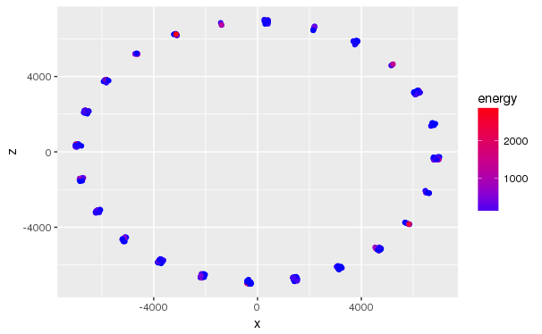

```r
calodf %>% ggplot(aes(x, z, color=energy)) +
      geom_point() + scale_colour_gradient(low = "blue", high="red")
```

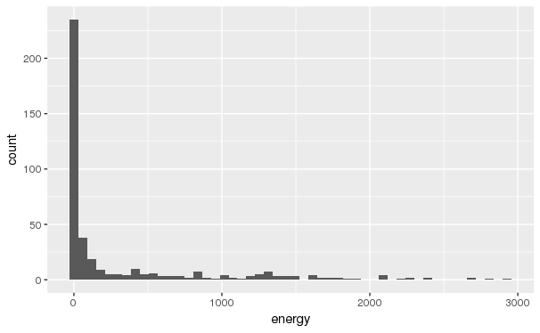

```r
calodf %>% ggplot(aes(energy)) + geom_histogram(bins=50)
```

Let’s find some files in XRoodD. Before I started `RStudio`, I set up `ifdhc` (and make sure my VOMS proxy valid). IFDH will convert the name to a partial XRootD URI.

```r
aFile <- system(
  "ifdh ls /pnfs/GM2/scratch/users/twalton/2017-02-16-15-15-44/data/gm2ringsim_muon_gas_gun_mdc0_17382039.530.root", intern = T)
aFile
```

```
[1] "/pnfs/fnal.gov/usr/GM2/scratch/users/twalton/2017-02-16-15-15-44/data/gm2ringsim_muon_gas_gun_mdc0_17382039.530.root"
```

We need to add a prefix to make the filename a real XRootD URI.

```r
xrdFiles <- paste0('root://fndca1.fnal.gov', aFile)
xrdFiles
```

```
[1] "root://fndca1.fnal.gov/pnfs/fnal.gov/usr/GM2/scratch/users/twalton/2017-02-16-15-15-44/data/gm2ringsim_muon_gas_gun_mdc0_17382039.530.root"
```

Let’s run it!

```r
calodf2 <- getGm2Events(xrdFiles)
```

```
Successfully opened file root://fndca1.fnal.gov/pnfs/fnal.gov/usr/GM2/scratch/users/twalton/2017-02-16-15-15-44/data/gm2ringsim_muon_gas_gun_mdc0_17382039.530.root
On file 0
Closing file, read 915724 bytes in 54 transactions
Processed 5000 events in an average of 144 microseconds/event
Total processing time (including file opening) was 3530 milliseconds
```

```r
calodf2
```

| eventEntry | fileEntry | turn | caloNum | parentID | particleName | x | y | z | px | py | pz | time | energy |
| --- | --- | --- | --- | --- | --- | --- | --- | --- | --- | --- | --- | --- | --- |
| 0 | 0 | 0 | 11 | 1 | e+ | -6970.8374 | 13.35832405 | 402.2009 | 3.983514e+01 | -1.341642e+00 | -1.646469e+02 | 162729.3438 | 168.8923950 |
| 0 | 0 | 0 | 11 | 4 | gamma | -6972.1035 | 13.53928757 | 402.1927 | 1.527655e+02 | 1.876776e+00 | -9.811552e+02 | 162729.3438 | 992.9785156 |
| 4 | 0 | 0 | 23 | 4 | gamma | 6827.0742 | 65.12972260 | -403.1293 | 1.373066e+01 | 7.613077e-01 | 5.221251e+01 | 59897.4570 | 53.9931145 |
| 4 | 0 | 0 | 21 | 4 | gamma | 5924.1572 | 69.34913635 | -3721.5361 | -5.864000e-02 | 8.840444e-02 | -1.390761e-01 | 59887.0469 | 0.1749175 |
| 4 | 0 | 0 | 22 | 4 | gamma | 6494.4795 | 35.17666626 | -2157.5105 | 2.988140e+01 | 9.605914e-01 | 8.578079e+01 | 59891.5312 | 90.8414230 |
| 4 | 0 | 0 | 22 | 217 | gamma | 6499.6167 | 7.21672010 | -2158.8516 | 6.539208e-01 | -2.397993e-02 | 1.851109e+00 | 59891.5352 | 1.9633622 |
| 4 | 0 | 0 | 22 | 4 | gamma | 6648.4917 | 39.64663315 | -2197.7139 | 1.674025e+01 | 5.323895e-01 | 3.710077e+01 | 59891.5977 | 40.7060966 |
| 4 | 0 | 0 | 22 | 378 | gamma | 6609.6694 | 43.72630310 | -2187.5796 | 3.309875e+00 | 1.304016e-01 | 7.872316e+00 | 59891.5781 | 8.5408220 |
| 5 | 0 | 0 | 13 | 1 | e+ | -6257.0967 | -17.14830399 | -3148.2795 | 1.275719e+03 | -7.921504e+00 | -1.963257e+03 | 101877.5781 | 2340.8352051 |
| 5 | 0 | 0 | 14 | 668 | gamma | -5114.9478 | 59.40688705 | -4544.8687 | 5.894942e+00 | 4.048567e-01 | -7.169583e+00 | 101883.6016 | 9.2907038 |

[output cut: 990 more lines]

```r
nrow(calodf2)
```

```
[1] 13810
```

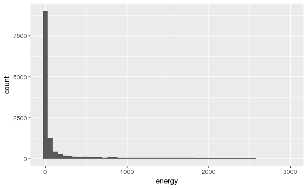

```r
calodf2 %>% ggplot(aes(energy)) + geom_histogram(bins=50)
```

Let’s try 10 files

```r
system(
  "ifdh ls /pnfs/GM2/scratch/users/twalton/2017-02-16-15-15-44/data/gm2ringsim_muon_gas_gun_mdc0_17382039.53?.root", intern = T) %>%
paste0('root://fndca1.fnal.gov', .) -> xrdManyFiles
xrdManyFiles <- xrdManyFiles[-1]   # ifdh ls returns the directory (need to ask MarcM if that can be turned off), drop it
xrdManyFiles
```

```
 [1] "root://fndca1.fnal.gov/pnfs/fnal.gov/usr/GM2/scratch/users/twalton/2017-02-16-15-15-44/data/gm2ringsim_muon_gas_gun_mdc0_17382039.530.root"
 [2] "root://fndca1.fnal.gov/pnfs/fnal.gov/usr/GM2/scratch/users/twalton/2017-02-16-15-15-44/data/gm2ringsim_muon_gas_gun_mdc0_17382039.533.root"
 [3] "root://fndca1.fnal.gov/pnfs/fnal.gov/usr/GM2/scratch/users/twalton/2017-02-16-15-15-44/data/gm2ringsim_muon_gas_gun_mdc0_17382039.536.root"
 [4] "root://fndca1.fnal.gov/pnfs/fnal.gov/usr/GM2/scratch/users/twalton/2017-02-16-15-15-44/data/gm2ringsim_muon_gas_gun_mdc0_17382039.537.root"
 [5] "root://fndca1.fnal.gov/pnfs/fnal.gov/usr/GM2/scratch/users/twalton/2017-02-16-15-15-44/data/gm2ringsim_muon_gas_gun_mdc0_17382039.538.root"
 [6] "root://fndca1.fnal.gov/pnfs/fnal.gov/usr/GM2/scratch/users/twalton/2017-02-16-15-15-44/data/gm2ringsim_muon_gas_gun_mdc0_17382039.532.root"
 [7] "root://fndca1.fnal.gov/pnfs/fnal.gov/usr/GM2/scratch/users/twalton/2017-02-16-15-15-44/data/gm2ringsim_muon_gas_gun_mdc0_17382039.531.root"
 [8] "root://fndca1.fnal.gov/pnfs/fnal.gov/usr/GM2/scratch/users/twalton/2017-02-16-15-15-44/data/gm2ringsim_muon_gas_gun_mdc0_17382039.539.root"
 [9] "root://fndca1.fnal.gov/pnfs/fnal.gov/usr/GM2/scratch/users/twalton/2017-02-16-15-15-44/data/gm2ringsim_muon_gas_gun_mdc0_17382039.535.root"
[10] "root://fndca1.fnal.gov/pnfs/fnal.gov/usr/GM2/scratch/users/twalton/2017-02-16-15-15-44/data/gm2ringsim_muon_gas_gun_mdc0_17382039.534.root"
```

Let’s get the data!

```r
calodf3 <- getGm2Events(xrdManyFiles)
```

```
Successfully opened file root://fndca1.fnal.gov/pnfs/fnal.gov/usr/GM2/scratch/users/twalton/2017-02-16-15-15-44/data/gm2ringsim_muon_gas_gun_mdc0_17382039.530.root
On file 0
Closing file, read 915724 bytes in 54 transactions
Successfully opened file root://fndca1.fnal.gov/pnfs/fnal.gov/usr/GM2/scratch/users/twalton/2017-02-16-15-15-44/data/gm2ringsim_muon_gas_gun_mdc0_17382039.533.root
On file 1
Closing file, read 880499 bytes in 37 transactions
Successfully opened file root://fndca1.fnal.gov/pnfs/fnal.gov/usr/GM2/scratch/users/twalton/2017-02-16-15-15-44/data/gm2ringsim_muon_gas_gun_mdc0_17382039.536.root
On file 2
Closing file, read 875090 bytes in 37 transactions
Successfully opened file root://fndca1.fnal.gov/pnfs/fnal.gov/usr/GM2/scratch/users/twalton/2017-02-16-15-15-44/data/gm2ringsim_muon_gas_gun_mdc0_17382039.537.root
On file 3
Closing file, read 906688 bytes in 37 transactions
Successfully opened file root://fndca1.fnal.gov/pnfs/fnal.gov/usr/GM2/scratch/users/twalton/2017-02-16-15-15-44/data/gm2ringsim_muon_gas_gun_mdc0_17382039.538.root
On file 4
Closing file, read 901136 bytes in 37 transactions
Successfully opened file root://fndca1.fnal.gov/pnfs/fnal.gov/usr/GM2/scratch/users/twalton/2017-02-16-15-15-44/data/gm2ringsim_muon_gas_gun_mdc0_17382039.532.root
On file 5
Closing file, read 881875 bytes in 37 transactions
Successfully opened file root://fndca1.fnal.gov/pnfs/fnal.gov/usr/GM2/scratch/users/twalton/2017-02-16-15-15-44/data/gm2ringsim_muon_gas_gun_mdc0_17382039.531.root
On file 6
Closing file, read 919385 bytes in 37 transactions
Successfully opened file root://fndca1.fnal.gov/pnfs/fnal.gov/usr/GM2/scratch/users/twalton/2017-02-16-15-15-44/data/gm2ringsim_muon_gas_gun_mdc0_17382039.539.root
On file 7
Closing file, read 907651 bytes in 37 transactions
Successfully opened file root://fndca1.fnal.gov/pnfs/fnal.gov/usr/GM2/scratch/users/twalton/2017-02-16-15-15-44/data/gm2ringsim_muon_gas_gun_mdc0_17382039.535.root
On file 8
Closing file, read 893688 bytes in 37 transactions
Successfully opened file root://fndca1.fnal.gov/pnfs/fnal.gov/usr/GM2/scratch/users/twalton/2017-02-16-15-15-44/data/gm2ringsim_muon_gas_gun_mdc0_17382039.534.root
On file 9
Closing file, read 905273 bytes in 37 transactions
Processed 50000 events in an average of 16 microseconds/event
Total processing time (including file opening) was 25969 milliseconds
```

```r
calodf3
```

| eventEntry | fileEntry | turn | caloNum | parentID | particleName | x | y | z | px | py | pz | time | energy |
| --- | --- | --- | --- | --- | --- | --- | --- | --- | --- | --- | --- | --- | --- |
| 0 | 0 | 0 | 11 | 1 | e+ | -6970.8374 | 13.35832405 | 402.2009 | 3.983514e+01 | -1.341642e+00 | -1.646469e+02 | 162729.3438 | 168.8923950 |
| 0 | 0 | 0 | 11 | 4 | gamma | -6972.1035 | 13.53928757 | 402.1927 | 1.527655e+02 | 1.876776e+00 | -9.811552e+02 | 162729.3438 | 992.9785156 |
| 4 | 0 | 0 | 23 | 4 | gamma | 6827.0742 | 65.12972260 | -403.1293 | 1.373066e+01 | 7.613077e-01 | 5.221251e+01 | 59897.4570 | 53.9931145 |
| 4 | 0 | 0 | 21 | 4 | gamma | 5924.1572 | 69.34913635 | -3721.5361 | -5.864000e-02 | 8.840444e-02 | -1.390761e-01 | 59887.0469 | 0.1749175 |
| 4 | 0 | 0 | 22 | 4 | gamma | 6494.4795 | 35.17666626 | -2157.5105 | 2.988140e+01 | 9.605914e-01 | 8.578079e+01 | 59891.5312 | 90.8414230 |
| 4 | 0 | 0 | 22 | 217 | gamma | 6499.6167 | 7.21672010 | -2158.8516 | 6.539208e-01 | -2.397993e-02 | 1.851109e+00 | 59891.5352 | 1.9633622 |
| 4 | 0 | 0 | 22 | 4 | gamma | 6648.4917 | 39.64663315 | -2197.7139 | 1.674025e+01 | 5.323895e-01 | 3.710077e+01 | 59891.5977 | 40.7060966 |
| 4 | 0 | 0 | 22 | 378 | gamma | 6609.6694 | 43.72630310 | -2187.5796 | 3.309875e+00 | 1.304016e-01 | 7.872316e+00 | 59891.5781 | 8.5408220 |
| 5 | 0 | 0 | 13 | 1 | e+ | -6257.0967 | -17.14830399 | -3148.2795 | 1.275719e+03 | -7.921504e+00 | -1.963257e+03 | 101877.5781 | 2340.8352051 |
| 5 | 0 | 0 | 14 | 668 | gamma | -5114.9478 | 59.40688705 | -4544.8687 | 5.894942e+00 | 4.048567e-01 | -7.169583e+00 | 101883.6016 | 9.2907038 |

[output cut: 990 more lines]

```r
library(dplyr)
library(tidyr)
```

Note that the event entries re-zero on a new file. So the unique id for an event is the combination of file entry and event entry.

```r
calodf3 %>% unite(f_e, fileEntry, eventEntry, sep="|") -> calodf3
calodf3
```

|  | f_e | turn | caloNum | parentID | particleName | x | y | z | px | py | pz | time | energy |
| --- | --- | --- | --- | --- | --- | --- | --- | --- | --- | --- | --- | --- | --- |
| 1 | 0\|0 | 0 | 11 | 1 | e+ | -6970.8374 | 13.35832405 | 402.2009 | 3.983514e+01 | -1.341642e+00 | -1.646469e+02 | 162729.3438 | 168.8923950 |
| 2 | 0\|0 | 0 | 11 | 4 | gamma | -6972.1035 | 13.53928757 | 402.1927 | 1.527655e+02 | 1.876776e+00 | -9.811552e+02 | 162729.3438 | 992.9785156 |
| 3 | 0\|4 | 0 | 23 | 4 | gamma | 6827.0742 | 65.12972260 | -403.1293 | 1.373066e+01 | 7.613077e-01 | 5.221251e+01 | 59897.4570 | 53.9931145 |
| 4 | 0\|4 | 0 | 21 | 4 | gamma | 5924.1572 | 69.34913635 | -3721.5361 | -5.864000e-02 | 8.840444e-02 | -1.390761e-01 | 59887.0469 | 0.1749175 |
| 5 | 0\|4 | 0 | 22 | 4 | gamma | 6494.4795 | 35.17666626 | -2157.5105 | 2.988140e+01 | 9.605914e-01 | 8.578079e+01 | 59891.5312 | 90.8414230 |
| 6 | 0\|4 | 0 | 22 | 217 | gamma | 6499.6167 | 7.21672010 | -2158.8516 | 6.539208e-01 | -2.397993e-02 | 1.851109e+00 | 59891.5352 | 1.9633622 |
| 7 | 0\|4 | 0 | 22 | 4 | gamma | 6648.4917 | 39.64663315 | -2197.7139 | 1.674025e+01 | 5.323895e-01 | 3.710077e+01 | 59891.5977 | 40.7060966 |
| 8 | 0\|4 | 0 | 22 | 378 | gamma | 6609.6694 | 43.72630310 | -2187.5796 | 3.309875e+00 | 1.304016e-01 | 7.872316e+00 | 59891.5781 | 8.5408220 |
| 9 | 0\|5 | 0 | 13 | 1 | e+ | -6257.0967 | -17.14830399 | -3148.2795 | 1.275719e+03 | -7.921504e+00 | -1.963257e+03 | 101877.5781 | 2340.8352051 |
| 10 | 0\|5 | 0 | 14 | 668 | gamma | -5114.9478 | 59.40688705 | -4544.8687 | 5.894942e+00 | 4.048567e-01 | -7.169583e+00 | 101883.6016 | 9.2907038 |

[output cut: 990 more lines]

```r
nrow(calodf3)
```

```
[1] 131232
```

We have 131232 entries in the data frame (calorimeter hits).

```r
calodf3 %>% summarize(total=n())
```

| total |
| --- |
| 131232 |

How many unique events do we have?

```r
calodf3 %>% group_by(f_e) %>% summarise(count=n()) %>% summarize(total=n())
```

| total |
| --- |
| 31624 |

Another way,

```r
calodf3 %>% select(f_e) %>% distinct() %>% nrow()
```

```
[1] 31624
```

Let’s make some plots!

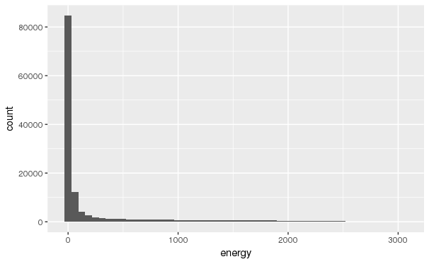

```r
calodf3 %>% ggplot(aes(energy)) + geom_histogram(bins=50)
```